# Self-Driving Car Engineer Nanodegree

## Project: Build a Traffic Sign Recognition Classifier

In this notebook, a template is provided for you to implement your functionality in stages, which is required to successfully complete this project. If additional code is required that cannot be included in the notebook, be sure that the Python code is successfully imported and included in your submission if necessary.

In addition to implementing code, there is a writeup to complete. The writeup should be completed in a separate file, which can be either a markdown file or a pdf document. There is a [write up template](https://github.com/udacity/CarND-Traffic-Sign-Classifier-Project/blob/master/writeup_template.md) that can be used to guide the writing process. Completing the code template and writeup template will cover all of the [rubric points](https://review.udacity.com/#!/rubrics/481/view) for this project.

The [rubric](https://review.udacity.com/#!/rubrics/481/view) contains "Stand Out Suggestions" for enhancing the project beyond the minimum requirements. The stand out suggestions are optional. If you decide to pursue the "stand out suggestions", you can include the code in this Ipython notebook and also discuss the results in the writeup file.

> **Note:** Code and Markdown cells can be executed using the **Shift + Enter** keyboard shortcut. In addition, Markdown cells can be edited by typically double-clicking the cell to enter edit mode.

```python
import numpy as np
import pandas as pd
import cv2
from sklearn.metrics import confusion_matrix
```

## Step 0: Load The Data

```python
# Load pickled data
import pickle

# TODO: Fill this in based on where you saved the training and testing data

training_file = 'traffic-signs-data/train.p'
validation_file= 'traffic-signs-data/valid.p'
testing_file = 'traffic-signs-data/test.p'

with open(training_file, mode='rb') as f:
    train = pickle.load(f)
with open(validation_file, mode='rb') as f:
    valid = pickle.load(f)
with open(testing_file, mode='rb') as f:
    test = pickle.load(f)

X_train, y_train = train['features'], train['labels']
X_valid, y_valid = valid['features'], valid['labels']
X_test, y_test = test['features'], test['labels']
```

## Step 1: Dataset Summary & Exploration

The pickled data is a dictionary with 4 key/value pairs:

- `'features'` is a 4D array containing raw pixel data of the traffic sign images, (num examples, width, height, channels).
- `'labels'` is a 1D array containing the label/class id of the traffic sign. The file `signnames.csv` contains id -> name mappings for each id.
- `'sizes'` is a list containing tuples, (width, height) representing the original width and height the image.
- `'coords'` is a list containing tuples, (x1, y1, x2, y2) representing coordinates of a bounding box around the sign in the image. **THESE COORDINATES ASSUME THE ORIGINAL IMAGE. THE PICKLED DATA CONTAINS RESIZED VERSIONS (32 by 32) OF THESE IMAGES**

Complete the basic data summary below. Use python, numpy and/or pandas methods to calculate the data summary rather than hard coding the results. For example, the [pandas shape method](http://pandas.pydata.org/pandas-docs/stable/generated/pandas.DataFrame.shape.html) might be useful for calculating some of the summary results.

The things to see:

```
* Assert that the number of images is the same as the number of labels in train/test/valid
* Assert that the shapes of images is the same in train/test/valid sets
* The number of images
* Distribution of image-labels
* Can I see how similar are the images to each other?
```

```python
# Assert that the number of images is the same as the number of labels in train/test/valid sets
assert(len(X_train) == len(y_train))
assert(len(X_valid) == len(y_valid))
assert(len(X_test) == len(y_test))
```

```python
# Assert that the shapes of images is the same train/test/valid sets
assert(X_train.shape[1:] == X_test.shape[1:])
assert(X_test.shape[1:] == X_valid.shape[1:])
```

### Provide a Basic Summary of the Data Set Using Python, Numpy and/or Pandas

```python
### Replace each question mark with the appropriate value.
### Use python, pandas or numpy methods rather than hard coding the results

# TODO: Number of training examples
n_train = len(X_train)

# TODO: Number of validation examples
n_validation = len(X_valid)

# TODO: Number of testing examples.
n_test = len(X_test)

# TODO: What's the shape of an traffic sign image?
image_shape = X_train.shape[1:]

# TODO: How many unique classes/labels there are in the dataset.
n_classes = len(np.unique(y_train))

print("Number of training examples =", n_train)
print("Number of validation examples =", n_validation)
print("Number of testing examples =", n_test)
print("Image data shape =", image_shape)
print("Number of classes =", n_classes)
```

```
Number of training examples = 34799
Number of validation examples = 4410
Number of testing examples = 12630
Image data shape = (32, 32, 3)
Number of classes = 43
```

### Include an exploratory visualization of the dataset

Visualize the German Traffic Signs Dataset using the pickled file(s). This is open ended, suggestions include: plotting traffic sign images, plotting the count of each sign, etc.

The [Matplotlib](http://matplotlib.org/) [examples](http://matplotlib.org/examples/index.html) and [gallery](http://matplotlib.org/gallery.html) pages are a great resource for doing visualizations in Python.

**NOTE:** It's recommended you start with something simple first. If you wish to do more, come back to it after you've completed the rest of the sections. It can be interesting to look at the distribution of classes in the training, validation and test set. Is the distribution the same? Are there more examples of some classes than others?

```python
### Data exploration visualization code goes here.
### Feel free to use as many code cells as needed.
import matplotlib.pyplot as plt
# Visualizations will be shown in the notebook.
%matplotlib inline
import seaborn as sns
```

### Plotting the counts of each label in training data

```python
# Read the signnames.csv into a pandas dataframe
df = pd.read_csv('signnames.csv', index_col=False)
g_SIGN_NAMES = df.SignName.values

# Utility function to return the counts of each label in the data
def get_counts_of_sign_name(y, dataFrame=df):
    """
    param y: List [1, 0, 1, 1, 1, 0, 0, 1]
    param dataFrame: pandas dataframe ["ClassId": {0, 1}, "SignName": {"Class0", "Class1"}]
    returns counts_of_sign_name :dict {"Class0": 3, ""Class1": 5}
    """
    counts_of_sign_name = {}
    for label in y:
        sign_name = dataFrame.loc[label, 'SignName']
        if sign_name not in counts_of_sign_name:
            counts_of_sign_name[sign_name] = 0
        counts_of_sign_name[sign_name] += 1
    return counts_of_sign_name
```

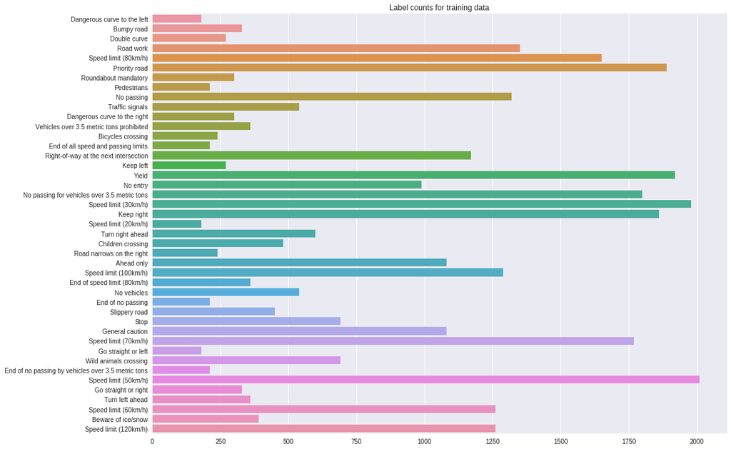

```python
# Create a dictionary which holds the counts of each sign in the training data
train_counts_of_sign_name = get_counts_of_sign_name(y_train)

# Puth the signs and the corresponding counts in a list, which will be used to plot
signs = []
train_counts = []
for k,v in train_counts_of_sign_name.items():
    signs.append(k)
    train_counts.append(v)

# Set appropriate figure size and plot the counts per sign name in training data
plt.figure(figsize=(16, 12))
ax = sns.barplot(train_counts, signs)
sns.plt.title("Label counts for training data")
sns.plt.savefig("examples/training_images_count.jpg")
sns.plt.show()
```

```python
print("Maximum datapoints is for {0} : {1}".format(signs[train_counts.index(max(train_counts))], max(train_counts)))
print("Minimum datapoints is for {0} : {1}".format(signs[train_counts.index(min(train_counts))], min(train_counts)))
print("Skew ratio : {0:.2f}".format(max(train_counts)/min(train_counts)))
```

```
Maximum datapoints is for Speed limit (50km/h) : 2010
Minimum datapoints is for Dangerous curve to the left : 180
Skew ratio : 11.17
```

The data in the training set does not seem to be uniformaly distributed amongst the 43 different classes. In particular, we have 11 times more data points for "Speed limit (50km/h)" as compared to "Speed limit (20km/h)".

### Compare training and validation data statistics

We will now explore whether the frequencies of the labels in the validation data matches the frequencies of labels in training data. For this, we compute perform a chi-squared test.

```
chisquared p value = 5.819875076936737e-10
```

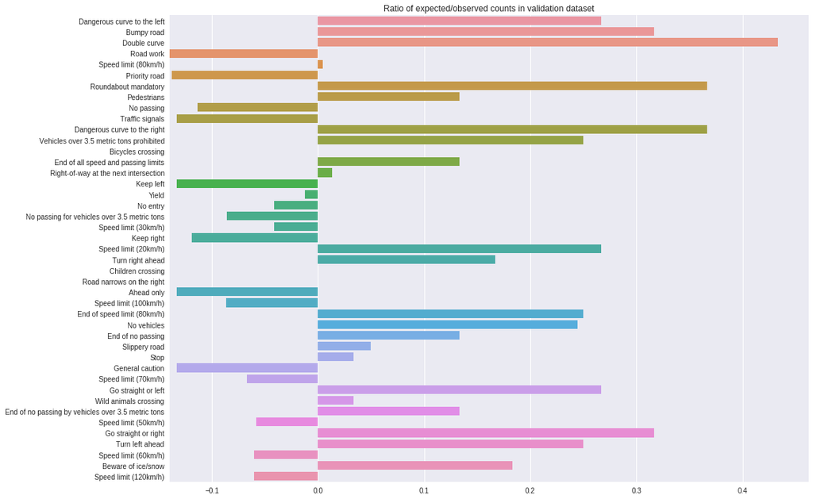

```python
from scipy.stats import chisquare

# For validation data, calculate the number of data points for each label
validation_counts_of_sign_name = get_counts_of_sign_name(y_valid)

# For validation data, calculate the expected number of data points for each label
# **if** the frequencies of training data is same as that of validation data
expected_validation_counts_of_sign_name = {sign_name: training_count * (len(y_valid)/len(y_train))
                                           for sign_name,training_count in train_counts_of_sign_name.items()}

observed = []
expected = []
signs = []
for k,_ in validation_counts_of_sign_name.items():
    signs.append(k)
    observed.append(int(validation_counts_of_sign_name[k]))
    expected.append(int(expected_validation_counts_of_sign_name[k]))

print("chisquared p value = {0}".format(chisquare(observed, f_exp=expected)[1]))

# Plot ratio of expected/observed for each sign
plt.figure(figsize=(16, 12))
ax = sns.barplot([1 - e/o for e,o in zip(expected, observed)], signs)
sns.plt.title("Ratio of expected/observed counts in validation dataset")
sns.plt.savefig("examples/training_valid_images_count.jpg")
sns.plt.show()
```

The distribution of the number of labes in training and validation datasets are significantly different as is quantified by the extremely small *p-value* and also seen from the above graph.

### Looking at some of actual images

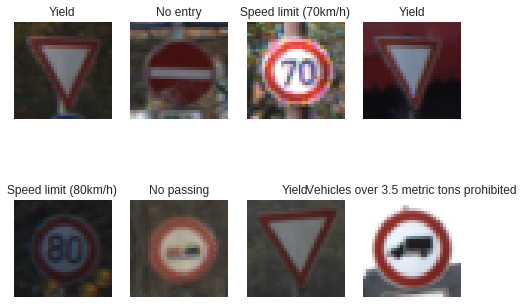

```python
import random

fig = plt.figure(figsize=(8,6))
num_images = 8
for i in range(1, num_images+1):
    image_number = 2 * 100 + int(num_images/2)*10 + i
    ax = fig.add_subplot(2, 4, i)
    ax.grid(False)
    index = random.randint(0, len(X_train))
    ax.imshow(X_train[index].squeeze())
    ax.set_title(df.loc[y_train[index], 'SignName'])
    plt.xticks([])
    plt.yticks([])
plt.show()
```

For certain images, it seems very difficult for me to actually find the correct class! It will be interesting to know what the actual human accuracy of the dataset is.

## Augmenting training data

```python
def random_brightness(image, ratio):
    """
    Randomly adjust brightness of the image.
    """
    # HSV (Hue, Saturation, Value) is also called HSB ('B' for Brightness).
    hsv = cv2.cvtColor(image, cv2.COLOR_RGB2HSV)
    brightness = np.float64(hsv[:, :, 2])
    brightness = brightness * (1.0 + np.random.uniform(-ratio, ratio))
    brightness[brightness>255] = 255
    brightness[brightness<0] = 0
    hsv[:, :, 2] = brightness
    return cv2.cvtColor(hsv, cv2.COLOR_HSV2RGB)


def random_rotation(image, angle):
    """
    Randomly rotate the image
    """
    if angle == 0:
        return image
    angle = np.random.uniform(-angle, angle)
    rows, cols = image.shape[:2]
    size = cols, rows
    center = cols/2, rows/2
    scale = 1.0
    rotation = cv2.getRotationMatrix2D(center, angle, scale)
    return cv2.warpAffine(image, rotation, size)


def random_translation(image, translation):
    """
    Randomly move the image
    """
    if translation == 0:
        return 0
    rows, cols = image.shape[:2]
    size = cols, rows
    x = np.random.uniform(-translation, translation)
    y = np.random.uniform(-translation, translation)
    trans = np.float32([[1,0,x],[0,1,y]])
    return cv2.warpAffine(image, trans, size)


def random_shear(image, shear):
    """
    Randomly distort the image
    """
    if shear == 0:
        return image
    rows, cols = image.shape[:2]
    size = cols, rows
    left, right, top, bottom = shear, cols - shear, shear, rows - shear
    dx = np.random.uniform(-shear, shear)
    dy = np.random.uniform(-shear, shear)
    p1 = np.float32([[left   , top],[right   , top   ],[left, bottom]])
    p2 = np.float32([[left+dx, top],[right+dx, top+dy],[left, bottom+dy]])
    move = cv2.getAffineTransform(p1,p2)
    return cv2.warpAffine(image, move, size)


def augment_image(image, brightness, angle, translation, shear):
    image = random_brightness(image, brightness)
    image = random_rotation(image, angle)
    image = random_translation(image, translation)
    image = random_shear(image, shear)
    return image
```

```python
X_augmented = []
y_augmented = []
initial_training_size = len(X_train)
for i in range(initial_training_size):

    x_new = augment_image(X_train[i], brightness=0.7, angle=10, translation=5, shear=2)
    y_new = y_train[i]
    #x_new = np.array(x_new).reshape((1, x_new.shape[0], x_new.shape[1], x_new.shape[2]))

    X_augmented.append(x_new)
    y_augmented.append(y_new)
```

```
index = 10479
```

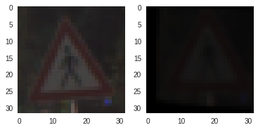

```python
# Compaer the original and augmented figure

fig = plt.figure(figsize=(6,6))
index = random.randint(0, len(X_train))
print("index = {}".format(index))

#index = 29664
ax = fig.add_subplot(1, 2, 1)
ax.grid(False)
ax.imshow(X_train[index].squeeze())

ax = fig.add_subplot(1, 2, 2)
ax.grid(False)
ax.imshow(X_augmented[index].squeeze())
plt.show()
```

```python
X_augmented = np.array(X_augmented)
y_augmented = np.array(y_augmented)
X_train = np.append(X_train, X_augmented, axis=0)
y_train = np.append(y_train, y_augmented, axis=0)
```

## Step 2: Design and Test a Model Architecture

Design and implement a deep learning model that learns to recognize traffic signs. Train and test your model on the [German Traffic Sign Dataset](http://benchmark.ini.rub.de/?section=gtsrb&subsection=dataset).

The LeNet-5 implementation shown in the classroom at the end of the CNN lesson is a solid starting point. You'll have to change the number of classes and possibly the preprocessing, but aside from that it's plug and play!

With the LeNet-5 solution from the lecture, you should expect a validation set accuracy of about 0.89. To meet specifications, the validation set accuracy will need to be at least 0.93. It is possible to get an even higher accuracy, but 0.93 is the minimum for a successful project submission.

There are various aspects to consider when thinking about this problem:

- Neural network architecture (is the network over or underfitting?)
- Play around preprocessing techniques (normalization, rgb to grayscale, etc)
- Number of examples per label (some have more than others).
- Generate fake data.

Here is an example of a [published baseline model on this problem](http://yann.lecun.com/exdb/publis/pdf/sermanet-ijcnn-11.pdf). It's not required to be familiar with the approach used in the paper but, it's good practice to try to read papers like these.

### Pre-process the Data Set (normalization, grayscale, etc.)

Minimally, the image data should be normalized so that the data has mean zero and equal variance. For image data, `(pixel - 128)/ 128` is a quick way to approximately normalize the data and can be used in this project.

Other pre-processing steps are optional. You can try different techniques to see if it improves performance.

Use the code cell (or multiple code cells, if necessary) to implement the first step of your project.

[figure not shown]

```python
# Compaer the original and transformed figure

fig = plt.figure(figsize=(6,6))
index = 29664
X_index = list(map(lambda x: (x - x.mean()) * 1. /x.std(), X_train[index]))
#print(len(X_index))
#print(np.asarray(X_index).shape)

ax = fig.add_subplot(1, 2, 1)
ax.grid(False)
ax.imshow(X_train[index].squeeze())

X_index = np.asarray(X_index)
ax = fig.add_subplot(1, 2, 2)
ax.grid(False)
ax.imshow(X_index.squeeze())
plt.show()
```

```python
g_is_normalized = False
```

```python
### Preprocess the data here. It is required to normalize the data. Other preprocessing steps could include
### converting to grayscale, etc.
from sklearn.utils import shuffle

# Normalize
if not g_is_normalized:
    print("Normalizing")
    X_train = list(map(lambda x: (x - x.mean()) * 1. /x.std(), X_train))
    X_test = list(map(lambda x: (x - x.mean()) * 1. /x.std(), X_test))
    X_valid = list(map(lambda x: (x - x.mean()) * 1. /x.std(), X_valid))
    g_is_normalized = True

    # Shuffle
#X_train, y_train = shuffle(X_train, y_train)
```

```
Normalizing
```

### Model Architecture for LeNet

| Layer # | Layer Type | Output Shape |
| --- | --- | --- |
| **Input** |  | 32x32x3 (3 because there are three color channels) |
| **1** | Convolutional | 28x28x24 |
| **1** | Activation (Relu) | 28x28x24 |
| **1** | Pooling (Max) | 14x14x24 |
| **2** | Convolutional | 10x10x64 |
| **2** | Activation (Relu) | 10x10x64 |
| **2** | Pooling (Max) | 5x5x64 |
|  | Flatten | 1600 |
| **3** | Fully Connected | 480 |
| **3** | Activation (Relu) | 480 |
| **4** | Fully Connected | 43 (The number of unique labes in the training data) |
| **Output** | Logits | 43 |

```python
import tensorflow as tf
from tensorflow.contrib.layers import flatten
EPOCHS = 50
BATCH_SIZE = 50
g_number_of_classes = 43

tf.reset_default_graph()
def LeNet(x, dropout):

    # Statistics of normal distribution to initialize weights of the convolutional neural nets.
    mu = 0
    sigma = 0.1

    # Layer 1
    conv1_W = tf.Variable(tf.truncated_normal([5, 5, 3, 24], mean=mu, stddev=sigma))
    conv1_b = tf.Variable(tf.zeros(24))
    l1 = tf.nn.conv2d(x, conv1_W, strides=[1, 1, 1, 1], padding='VALID')
    l1 = tf.nn.bias_add(l1, conv1_b)
    l1 = tf.nn.relu(l1)
    l1 = tf.nn.max_pool(l1, ksize=[1, 2, 2, 1], strides=[1, 2, 2, 1], padding='VALID')

    # Layer 2
    conv2_W = tf.Variable(tf.truncated_normal([5, 5, 24, 64], mean=mu, stddev=sigma))
    conv2_b = tf.Variable(tf.zeros(64))
    l2 = tf.nn.conv2d(l1, conv2_W, strides=[1, 1, 1, 1], padding='VALID')
    l2 = tf.nn.bias_add(l2, conv2_b)
    l2 = tf.nn.relu(l2)
    l2 = tf.nn.max_pool(l2, ksize=[1, 2, 2, 1], strides=[1, 2, 2, 1], padding='VALID')

    flat_l2 = flatten(l2)

    # Layer 3
    in_neurons = 5*5*64
    out_neurons = 480
    fc3_W = tf.Variable(tf.random_normal([in_neurons, out_neurons], mean=mu, stddev=np.sqrt(2.0/in_neurons)))
    fc3_b = tf.Variable(tf.zeros(out_neurons))
    l3 = tf.add(tf.matmul(flat_l2, fc3_W), fc3_b)
    l3 = tf.nn.relu(l3)
    l3 = tf.nn.dropout(l3, dropout)

    """
    # Layer 4
    in_neurons = out_neurons
    out_neurons = 240
    fc4_W = tf.Variable(tf.random_normal([in_neurons, out_neurons], mean=mu, stddev=np.sqrt(2.0/in_neurons)))
    fc4_b = tf.Variable(tf.zeros(240))
    l4 = tf.add(tf.matmul(l3, fc4_W), fc4_b)
    l4 = tf.nn.relu(l4)
    l4 = tf.nn.dropout(l4, dropout)
    """
    l4 = l3 # Remove this if you want l4 to be different!

    # Layer 5
    in_neurons = out_neurons
    out_neurons = g_number_of_classes
    fc5_W = tf.Variable(tf.random_normal([in_neurons, out_neurons],
                                         mean=mu,
                                         stddev=np.sqrt(2.0/in_neurons)))
    fc5_b = tf.Variable(tf.zeros(g_number_of_classes))
    logits = tf.add(tf.matmul(l4, fc5_W), fc5_b)

    return logits
```

```python
keep_prob = tf.placeholder(tf.float32)
x = tf.placeholder(tf.float32, (None, 32, 32, 3))
y = tf.placeholder(tf.int32, (None))
one_hot_y = tf.one_hot(y, g_number_of_classes)
```

### Train, Validate and Test the Model

A validation set can be used to assess how well the model is performing. A low accuracy on the training and validation sets imply underfitting. A high accuracy on the training set but low accuracy on the validation set implies overfitting.

```python
### Train your model here.
### Calculate and report the accuracy on the training and validation set.
### Once a final model architecture is selected,
### the accuracy on the test set should be calculated and reported as well.
### Feel free to use as many code cells as needed.
```

```python
# Creating the training operation

learning_rate = 0.0005

logits = LeNet(x, keep_prob)
cross_entropy = tf.nn.softmax_cross_entropy_with_logits(labels=one_hot_y, logits=logits)
loss = tf.reduce_mean(cross_entropy)
optimizer = tf.train.AdamOptimizer(learning_rate=learning_rate)
training_operation = optimizer.minimize(loss)
```

```python
# Evaluating the accuracy

correct_prediction = tf.equal(tf.argmax(logits, 1), tf.argmax(one_hot_y, 1))
accuracy_operation = tf.reduce_mean(tf.cast(correct_prediction, tf.float32))
saver = tf.train.Saver()

def evaluate(X_data, y_data):
    num_examples = len(X_data)
    total_accuracy = 0
    sess = tf.get_default_session()
    for offset in range(0, num_examples, BATCH_SIZE):
        batch_x, batch_y = X_data[offset:offset+BATCH_SIZE], y_data[offset:offset+BATCH_SIZE]
        accuracy = sess.run(accuracy_operation, feed_dict={x: batch_x, y: batch_y, keep_prob: 1.0})
        total_accuracy += (accuracy * len(batch_x))
    return total_accuracy / num_examples
```

```python
# Plotting training and validation accuracy
def show_learning_curve(training_accuracy, validation_accuracy):
    plt.plot(range(len(training_accuracy)), training_accuracy)
    plt.plot(range(len(validation_accuracy)), validation_accuracy)
    plt.axis((0, max(len(training_accuracy), len(validation_accuracy)) - 1, 0.6, 1.0))
    plt.show()
```

```
Training...

EPOCH 1 ...
Validation Accuracy = 0.892
Training Accuracy = 0.910

EPOCH 2 ...
Validation Accuracy = 0.929
Training Accuracy = 0.970

EPOCH 3 ...
Validation Accuracy = 0.949
Training Accuracy = 0.986

EPOCH 4 ...
Validation Accuracy = 0.943
Training Accuracy = 0.991

EPOCH 5 ...
Validation Accuracy = 0.952
Training Accuracy = 0.995

EPOCH 6 ...
Validation Accuracy = 0.950
Training Accuracy = 0.996

EPOCH 7 ...
Validation Accuracy = 0.943
Training Accuracy = 0.996

EPOCH 8 ...
Validation Accuracy = 0.929
Training Accuracy = 0.997

EPOCH 9 ...
Validation Accuracy = 0.948
Training Accuracy = 0.993

EPOCH 10 ...
Validation Accuracy = 0.954
```

[output cut: 146 more lines]

```
EPOCH 47 ...
Validation Accuracy = 0.971
Training Accuracy = 1.000

EPOCH 48 ...
Validation Accuracy = 0.965
Training Accuracy = 1.000

EPOCH 49 ...
Validation Accuracy = 0.963
Training Accuracy = 1.000

EPOCH 50 ...
Validation Accuracy = 0.972
Training Accuracy = 1.000
```

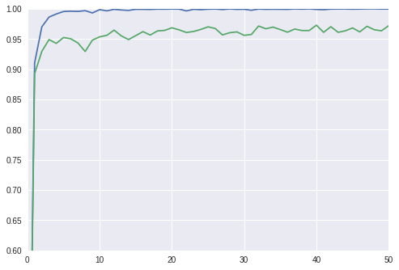

```
Model saved
```

```python
# Training

with tf.Session() as sess:
    sess.run(tf.global_variables_initializer())
    num_examples = len(X_train)

    print("Training...")
    print()
    training_accuracy = [0]
    validation_accuracy = [0]
    for i in range(EPOCHS):
        X_train, y_train = shuffle(X_train, y_train)
        for offset in range(0, num_examples, BATCH_SIZE):
            end = offset + BATCH_SIZE
            batch_x, batch_y = X_train[offset:end], y_train[offset:end]
            sess.run(training_operation, feed_dict={x: batch_x, y: batch_y, keep_prob: 0.70})

        training_accuracy.append(evaluate(X_train, y_train))
        validation_accuracy.append(evaluate(X_valid, y_valid))
        print("EPOCH {} ...".format(i+1))
        print("Validation Accuracy = {:.3f}".format(validation_accuracy[-1]))
        print("Training Accuracy = {:.3f}".format(training_accuracy[-1]))
        print()

    show_learning_curve(training_accuracy, validation_accuracy)

    saver.save(sess, './lenet')
    print("Model saved")
```

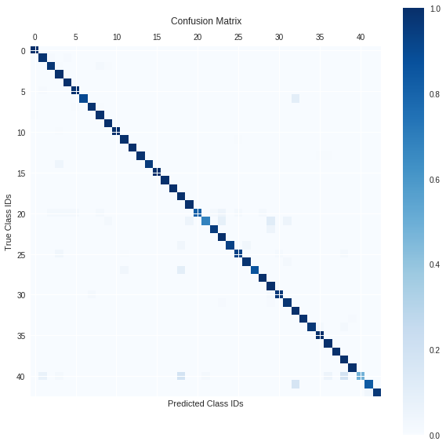

```python
# examine confusionconfusion_matrixix

def plot_confusion_matrix(cm):
    cm = [row/sum(row)   for row in cm]
    fig = plt.figure(figsize=(10, 10))
    ax = fig.add_subplot(111)
    cax = ax.matshow(cm, cmap=plt.cm.Blues)
    fig.colorbar(cax)
    plt.title('Confusion Matrix')
    plt.xlabel('Predicted Class IDs')
    plt.ylabel('True Class IDs')
    plt.show()

def print_confusion_matrix(cm, y, sign_names=g_SIGN_NAMES):
    results = [(i, sign_names[i], row[i]/sum(row)*100) for i, row in enumerate(cm)]
    accuracies = []
    for result in sorted(results, key=lambda x: -x[2]):
        print('{:>2} {:<50} {:6.2f}% {:>4}'.format(*result, sum(y==result[0])))
        accuracies.append(result[2])
    print('-'*50)
    print('Accuracy: Mean: {:.3f} Std: {:.3f}'.format(np.mean(accuracies), np.std(accuracies)))


with tf.Session() as sess:
    ckpt = tf.train.get_checkpoint_state('.')
    if ckpt and ckpt.model_checkpoint_path:
        saver.restore(sess, ckpt.model_checkpoint_path)
    else:
        print("no checkpint found")
    prob = tf.nn.softmax(logits)
    pred = sess.run(prob, feed_dict={x: X_valid, keep_prob:1.0})
    cm = confusion_matrix(y_valid, np.argmax(pred, axis=1))
    plot_confusion_matrix(cm)
    #print_confusion_matrix(cm, y_valid)
```

```python
# Analyze why "Roundabout mandatory" is poerforming poorly

X_round_about_mandatory = []
y_round_about_mandatory_pred = []
with tf.Session() as sess:
    ckpt = tf.train.get_checkpoint_state('.')
    if ckpt and ckpt.model_checkpoint_path:
        saver.restore(sess, ckpt.model_checkpoint_path)
    else:
        print("no checkpint found")
    X_round_about_mandatory = [x for x,y in zip(X_valid, y_valid) if y==40]
    X_round_about_mandatory = np.array(X_round_about_mandatory).reshape((len(X_round_abount_mandatory),
                                                                           X_round_about_mandatory[0].shape[0],
                                                                           X_round_about_mandatory[0].shape[1],
                                                                           X_round_about_mandatory[0].shape[2]))
    prob = tf.nn.softmax(logits)
    pred = sess.run(prob, feed_dict={x: X_round_about_mandatory, keep_prob:1.0})
    y_round_about_mandatory_pred = np.argmax(pred, axis=1)
    predicted_sign_counts_for_round_about = {g_SIGN_NAMES[sign]:sum(np.argmax(pred, axis=1)==sign) for sign in np.unique(np.argmax(pred, axis=1))}
    print(predicted_sign_counts_for_round_about)
```

```
{'Keep right': 11, 'Speed limit (60km/h)': 1, 'Double curve': 1, 'General caution': 11, 'Roundabout mandatory': 29, 'Go straight or right': 3, 'Speed limit (30km/h)': 4}
```

## Step 3: Test a Model on New Images

To give yourself more insight into how your model is working, download at least five pictures of German traffic signs from the web and use your model to predict the traffic sign type.

You may find `signnames.csv` useful as it contains mappings from the class id (integer) to the actual sign name.

### Load and Output the Images

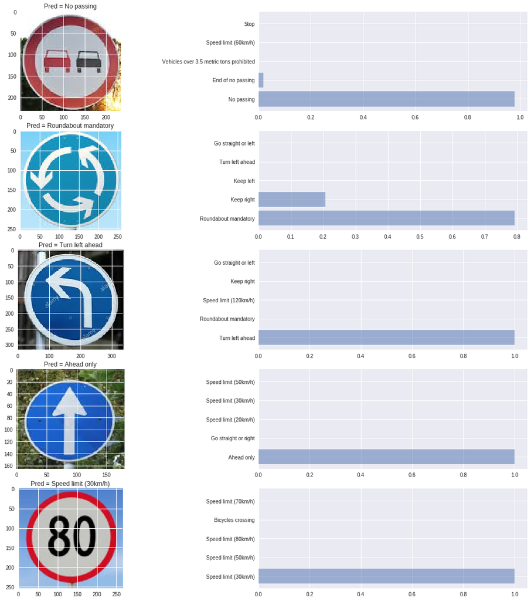

```python
### Load the images and plot them here.
### Feel free to use as many code cells as needed.
import os, sys
import numpy as np
from PIL import Image
import warnings
from skimage import exposure
import matplotlib.image as mpimg

### Histogram Equilization
def normalized_image(image_data):
    image_data = list(map(lambda x: (x - x.mean()) * 1. /x.std(), image_data))
    return np.asarray(image_data)

size = 32, 32
channels = 3
logit = []
num_predictions = 5

with tf.Session() as sess:
    loader = tf.train.import_meta_graph('lenet.meta')
    loader.restore(sess, tf.train.latest_checkpoint('./'))
    sess = tf.get_default_session()


    fig = plt.figure(figsize=(20,20))
    i = 0
    for file in os.listdir('images'):
        if '.png' in file:
            # Open image
            im = Image.open('images/' + file)

            # Resize image
            im.thumbnail(size, Image.ANTIALIAS)
            im = im.resize([32, 32], Image.FIXED)

            # Convert to RGB
            im = im.convert('RGB')

            # Convert to numpy
            image_array = np.asarray(im)

            # Normalize
            im_normalized = normalized_image(image_array)

            # Reshape dimension 32x32x3 --> 1x32x32x3
            im_normalized = im_normalized.reshape((1,
                                                   im_normalized.shape[0],
                                                   im_normalized.shape[1],
                                                   im_normalized.shape[2]))

            # Calculate the logit
            current_logit = sess.run(tf.nn.softmax(logits), feed_dict={x:im_normalized, keep_prob:1.0})
            logit.append(current_logit)

            # Plot the image
            ax = fig.add_subplot(5,2,i+1)
            img = mpimg.imread('images/' + file)
            ax.imshow(img)
            i+=1

            # Set the prediction
            prediction = g_SIGN_NAMES[np.argmax(current_logit)]
            ax.set_title('Pred = {}'.format(prediction))

            # Get top 5 predictions
            top_predictions = sess.run(tf.nn.top_k(np.asarray(current_logit), k=num_predictions))
            #print(top_predictions.values)

            # Plot the prediction
            ax = fig.add_subplot(5,2,i+1)
            y_pos = np.arange(num_predictions)
            plt.yticks(y_pos, [g_SIGN_NAMES[top_predictions.indices[0][idx]] for idx in y_pos])
            plt.barh(y_pos, top_predictions.values[0], align='center', alpha=0.5)
            i+=1

    plt.show()
```

## Accuracy

The model was able to correctly classify 4 out of the five new images thus having an accuracy of 80%. The one image which was incorrectly classified is the **Speed limit (80km/h)** sign which was predicted as **Speed limit (30km/h)**. The reason of this could be because of the incorrect featurization of the digit 8 which may have led to **8~3**.

### Project Writeup

Once you have completed the code implementation, document your results in a project writeup using this [template](https://github.com/udacity/CarND-Traffic-Sign-Classifier-Project/blob/master/writeup_template.md) as a guide. The writeup can be in a markdown or pdf file.

## Test Images

We now look at the accuracy of prediction for test images. This data set **is used only once** after the model was finalized.

```python
with tf.Session() as sess:
    loader = tf.train.import_meta_graph('lenet.meta')
    loader.restore(sess, tf.train.latest_checkpoint('./'))
    sess = tf.get_default_session()
    accuracy = sess.run(accuracy_operation, feed_dict={x: X_test, y: y_test, keep_prob: 1.0})
    print(accuracy)
```

```
0.952177
```

## Step 4 (Optional): Visualize the Neural Network's State with Test Images

This Section is not required to complete but acts as an additional excersise for understaning the output of a neural network's weights. While neural networks can be a great learning device they are often referred to as a black box. We can understand what the weights of a neural network look like better by plotting their feature maps. After successfully training your neural network you can see what it's feature maps look like by plotting the output of the network's weight layers in response to a test stimuli image. From these plotted feature maps, it's possible to see what characteristics of an image the network finds interesting. For a sign, maybe the inner network feature maps react with high activation to the sign's boundary outline or to the contrast in the sign's painted symbol.

Provided for you below is the function code that allows you to get the visualization output of any tensorflow weight layer you want. The inputs to the function should be a stimuli image, one used during training or a new one you provided, and then the tensorflow variable name that represents the layer's state during the training process, for instance if you wanted to see what the LeNet lab's feature maps looked like for it's second convolutional layer you could enter conv2 as the tf_activation variable.

For an example of what feature map outputs look like, check out NVIDIA's results in their paper [End-to-End Deep Learning for Self-Driving Cars](https://devblogs.nvidia.com/parallelforall/deep-learning-self-driving-cars/) in the section Visualization of internal CNN State. NVIDIA was able to show that their network's inner weights had high activations to road boundary lines by comparing feature maps from an image with a clear path to one without. Try experimenting with a similar test to show that your trained network's weights are looking for interesting features, whether it's looking at differences in feature maps from images with or without a sign, or even what feature maps look like in a trained network vs a completely untrained one on the same sign image.

[figure not shown]

Your output should look something like this (above)

```python
### Visualize your network's feature maps here.
### Feel free to use as many code cells as needed.

# image_input: the test image being fed into the network to produce the feature maps
# tf_activation: should be a tf variable name used during your training procedure that represents the calculated state of a specific weight layer
# activation_min/max: can be used to view the activation contrast in more detail, by default matplot sets min and max to the actual min and max values of the output
# plt_num: used to plot out multiple different weight feature map sets on the same block, just extend the plt number for each new feature map entry

def outputFeatureMap(image_input, tf_activation, activation_min=-1, activation_max=-1 ,plt_num=1):
    # Here make sure to preprocess your image_input in a way your network expects
    # with size, normalization, ect if needed
    # image_input =
    # Note: x should be the same name as your network's tensorflow data placeholder variable
    # If you get an error tf_activation is not defined it maybe having trouble accessing the variable from inside a function
    activation = tf_activation.eval(session=sess,feed_dict={x : image_input, apply_dropout: False})
    featuremaps = activation.shape[3]
    plt.figure(plt_num, figsize=(15,15))
    for featuremap in range(featuremaps):
        plt.subplot(6,8, featuremap+1) # sets the number of feature maps to show on each row and column
        plt.title('FeatureMap ' + str(featuremap)) # displays the feature map number
        if activation_min != -1 & activation_max != -1:
            plt.imshow(activation[0,:,:, featuremap], interpolation="nearest", vmin =activation_min, vmax=activation_max, cmap="gray")
        elif activation_max != -1:
            plt.imshow(activation[0,:,:, featuremap], interpolation="nearest", vmax=activation_max, cmap="gray")
        elif activation_min !=-1:
            plt.imshow(activation[0,:,:, featuremap], interpolation="nearest", vmin=activation_min, cmap="gray")
        else:
            plt.imshow(activation[0,:,:, featuremap], interpolation="nearest", cmap="gray")
```